# Getting data from the web

```r
library(rvest)
```

The page that we want to use uses outdated SSL. You may be able to skip this step, but my computer doesn’t connect to the website unless I tell it explicitly to allow the old SSL.

```r
httr::set_config(httr::config(ssl_cipher_list = "DEFAULT@SECLEVEL=1"))
```

Let’s download the page. You may be able to pass the URL directly to `read_html()`, but if you need to downgrade security, like I mentioned, then you can instead pass the request through `httr::GET()`.

```r
page <- read_html(httr::GET("https://www.ultimaterollercoaster.com/coasters/parks/canadas-wonderland"))
```

```r
page
```

```
{html_document}
<html>
[1] <head>\n<title>Canada's Wonderland - Vaughan, Ontario - Roller Coasters</title>\n<meta name="description" content="Plan ...
[2] <body>\n\n<div id="wrapper">\n\t<div id="headeruser">\n\n\t<p class="user">Members, <a rel="nofollow" href="/login.php" ...
```

Let’s extract any tables from the page.

```r
glimpse(tables)
```

```
List of 2
 $ : tibble [18 × 4] (S3: tbl_df/tbl/data.frame)
  ..$ Roller Coaster: chr [1:18] "Snoopy's Racing Railway" "Yukon Striker" "Wonder Mountain's Guardian" "Leviathan" ...
  ..$ Year          : int [1:18] 2023 2019 2014 2012 2008 2005 2004 2001 1999 1998 ...
  ..$ Track         : chr [1:18] "Steel" "Steel" "Steel" "Steel" ...
  ..$ Designer      : chr [1:18] "ART Engineering GmbH" "Bolliger & Mabillard" "ART Engineering GmbH" "Bolliger & Mabillard" ...
 $ : tibble [1 × 4] (S3: tbl_df/tbl/data.frame)
  ..$ X1: chr "Skyrider"
  ..$ X2: int 1985
  ..$ X3: chr "Steel"
  ..$ X4: chr "Togo"
```

The webpage has two tables. One is the “operational table”, and one is for decomissioned coasters. Let’s focus on the operating ones!

```r
tab <- tables[[1]]
tab
```

| Roller Coaster | Year | Track | Designer |
| --- | --- | --- | --- |
| Snoopy's Racing Railway | 2023 | Steel | ART Engineering GmbH |
| Yukon Striker | 2019 | Steel | Bolliger & Mabillard |
| Wonder Mountain's Guardian | 2014 | Steel | ART Engineering GmbH |
| Leviathan | 2012 | Steel | Bolliger & Mabillard |
| Behemoth | 2008 | Steel | Bolliger & Mabillard |
| Backlot Stunt Coaster | 2005 | Steel | Premier Rides |
| Time Warp | 2004 | Steel | Zamperla |
| Silver Streak | 2001 | Steel | Vekoma |
| The Fly | 1999 | Steel | Mack |
| Taxi Jam | 1998 | Steel | Miler Coaster, Inc. |

[output cut: 8 more lines]

The table doesn’t include coaster stats, so let’s look for them. In the original table, each of the coaster names was linked. Let’s extract all of the links in the table (the “a” nodes), and get the link location (identified by “href”).

```r
head(links)
```

```
[1] "/login.php"    "/register.php" "/"             "/"             "/coasters/"    "/themeparks/"
```

Ugh! Relative links. No thank you.

```r
head(links)
```

```
[1] "https://www.ultimaterollercoaster.com/login.php"    "https://www.ultimaterollercoaster.com/register.php"
[3] "https://www.ultimaterollercoaster.com/"             "https://www.ultimaterollercoaster.com/"
[5] "https://www.ultimaterollercoaster.com/coasters/"    "https://www.ultimaterollercoaster.com/themeparks/"
```

The links aren’t very useful unless we know that they were labelled as. Let’s get the text of each link too.

```r
head(link_names)
```

```
[1] "Log In"                 "Sign Up"                "Ultimate Rollercoaster" "Ultimate Rollercoaster"
[5] "Rollercoasters"         "Theme Parks"
```

Now let’s build a table.

| name | link |
| --- | --- |
| Log In | https://www.ultimaterollercoaster.com/login.php |
| Sign Up | https://www.ultimaterollercoaster.com/register.php |
| Ultimate Rollercoaster | https://www.ultimaterollercoaster.com/ |
| Ultimate Rollercoaster | https://www.ultimaterollercoaster.com/ |
| Rollercoasters | https://www.ultimaterollercoaster.com/coasters/ |
| Theme Parks | https://www.ultimaterollercoaster.com/themeparks/ |
| Thrill Rides | https://www.ultimaterollercoaster.com/thrillrides/ |
| Theme Park Tickets & Hotels | https://www.ultimaterollercoaster.com/hotels/ |
| Discussion Forums | https://www.ultimaterollercoaster.com/forums/ |
| News | https://www.ultimaterollercoaster.com/news/ |

[output cut: 59 more lines]

Now we can cross reference our coaster table with our link table.

```r
tab <- left_join(tab, links, by = c("Roller Coaster" = "name"))
tab
```

| Roller Coaster | Year | Track | Designer | link |
| --- | --- | --- | --- | --- |
| Snoopy's Racing Railway | 2023 | Steel | ART Engineering GmbH | https://www.ultimaterollercoaster.com/coasters/snoopys-racing-railway |
| Yukon Striker | 2019 | Steel | Bolliger & Mabillard | https://www.ultimaterollercoaster.com/coasters/yukon-striker |
| Wonder Mountain's Guardian | 2014 | Steel | ART Engineering GmbH | https://www.ultimaterollercoaster.com/coasters/wonder-mountains-guardian |
| Leviathan | 2012 | Steel | Bolliger & Mabillard | https://www.ultimaterollercoaster.com/coasters/leviathan |
| Behemoth | 2008 | Steel | Bolliger & Mabillard | https://www.ultimaterollercoaster.com/coasters/behemoth_canadas-wonderland |
| Backlot Stunt Coaster | 2005 | Steel | Premier Rides | https://www.ultimaterollercoaster.com/coasters/backlot-stunt-coaster |
| Time Warp | 2004 | Steel | Zamperla | https://www.ultimaterollercoaster.com/coasters/time-warp |
| Silver Streak | 2001 | Steel | Vekoma | https://www.ultimaterollercoaster.com/coasters/silver-streak |
| The Fly | 1999 | Steel | Mack | https://www.ultimaterollercoaster.com/coasters/the-fly |
| Taxi Jam | 1998 | Steel | Miler Coaster, Inc. | https://www.ultimaterollercoaster.com/coasters/taxijam |

[output cut: 8 more lines]

So now we know a couple of things:

1. The name of each coaster
2. Where we can find its profile page

We still don’t know anything about how awesome these coasters are!

Let’s look at a single page, and the we can generalize across the other pages. Leviathan is one of the biggest Wonderland coasters, let’s check it out.

```r
lev
```

```
{html_document}
<html>
[1] <head>\n<title>Leviathan - Canada's Wonderland - Roller Coasters</title>\n<meta name="description" content="Details about Leviathan roller coaster at Canada's Wonder ...
[2] <body>\n\n<div id="wrapper">\n\t<div id="headeruser">\n\n\t<p class="user">Members, <a rel="nofollow" href="/login.php">Log In</a>. Not a member? <a rel="nofollow" h ...
```

```r
stats
```

```
{html_node}
<div class="rc_stats">
[1] <ul>\n<li>\n\t\t\t\t<div class="stat">Height</div>\n\t\t\t\t<div class="stat-value">306</div>\n\t\t\t\t<div class="measure">feet</div>\n\t\t\t</li>\n\t\t\t<li>\n\t\t ...
```

Now we can extract the stats, which are classes labelled “stat” and “stat-value”, respectively, and do some reshaping, and unit converting.

```r
tibble(metric = stats %>% html_elements(".stat") %>% html_text(),
       value = stats %>% html_elements(".stat-value") %>% html_text()) %>%
  filter(metric %in% c("Height", "Top Speed")) %>%
  pivot_wider(names_from = "metric", values_from = "value") %>%
  rename(Speed = `Top Speed`) %>%
  mutate(Height = as.numeric(str_extract(Height, "[0-9]+")) * 0.3048,
         Speed = as.numeric(str_extract(Speed, "[0-9]+")) * 1.609344)
```

| Height | Speed |
| --- | --- |
| 93.2688 | 148.0596 |

So, we got one coaster done. It was a lot of work, and I don’t want to do that to each one, so let’s get crazy with a function! I also created a template to force select only the values I am interested in, as some coasters don’t have the stats we are looking for.

| Height | Speed |
| --- | --- |
| NA | 49.88966 |

Apply it to each link, and do a little cleanup.

```r
tab %>%
  mutate(stats = map(link, ~(stats(.)))) %>%
  unnest_wider(stats) %>%
  filter(!is.na(Height) & !is.na(Speed)) %>%
  select(-link) -> tab
```

Let’s have a look!

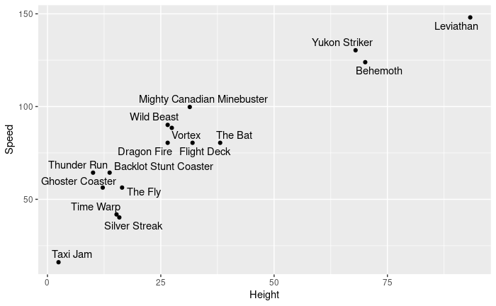

```r
library(ggrepel)
ggplot(tab, aes(x = Height, y = Speed, label = `Roller Coaster`)) +
  geom_point() +
  geom_text_repel()
```

I’ll save this data to use elsewhere in the workshop.

```r
write_csv(tab, "data/coasters.csv")
```